# Trabajo Practico 2 - Econometria

### a) Generación de Variables

Generar 4 variables: una que represente el salario semanal en pesos, dos variables binarias: género y una que represente si estudió en una universidad pública o privada.

Según un estudio de la consultora Ekonomía en 2021, los graduados de universidades privadas en Argentina ganaban en promedio un 27% más que los graduados de universidades públicas al inicio de sus carreras laborales.

Esta brecha salarial tendía a disminuir con los años de experiencia, pero aún se mantenía una diferencia del 17% a favor de los egresados de instituciones privadas después de 10 años de haber obtenido el título.

Las carreras con mayores brechas salariales eran las relacionadas con negocios, administración y finanzas, mientras que en áreas como ingeniería y ciencias exactas, la diferencia era menor.

Cuál es la diferencia de sueldos en base a la experiencia en egresados universidad en argentina

1. Estudio de PwC Argentina (2021):
- Los salarios iniciales de recién graduados universitarios eran un 35% menores que los de profesionales con 5 años de experiencia.
- Después de 10 años de experiencia, los salarios aumentaban en promedio un 80% en comparación con los ingresos iniciales.
2. Informe del Observatorio de Inserción Profesional de la UBA (2020):
- Los graduados de carreras de grado de la Universidad de Buenos Aires duplicaban sus ingresos después de 5 años de experiencia laboral.
- La brecha salarial entre recién egresados y profesionales con más de 10 años de experiencia podía llegar al 120% en algunas disciplinas.
3. Encuesta de Salarios de Profesionales de KPMG (2019):
- Los salarios promedio de profesionales argentinos con menos de 2 años de experiencia eran un 45% menores que los de aquellos con más de 10 años de trayectoria laboral.

¿Cuál es la diferencia o la brecha entre varones y mujeres universitarias con respecto al sueldo.?

algunos hallazgos e investigaciones previas sobre este tema en Argentina, teniendo en cuenta que la situación podría haber cambiado:

- Según un estudio del Ministerio de Economía de Argentina en 2021, las mujeres egresadas de universidades ganaban en promedio un 27% menos que sus pares hombres al iniciar sus carreras laborales.
- El informe “Brechas de Género en la Educación Superior” del Banco Mundial (2020) encontró que la brecha salarial entre hombres y mujeres profesionales en Argentina oscilaba entre el 15% y el 25%, dependiendo del campo de estudio.
- Una encuesta de la consultora Mercer (2019) reveló que la brecha salarial de género entre egresados universitarios en Argentina era de aproximadamente 22% a favor de los hombres, incluso después de controlar por factores como experiencia, nivel educativo y puesto de trabajo.
- Según datos del Observatorio de Inserción Profesional de la UBA (2018), las graduadas mujeres de carreras de grado de esa universidad percibían salarios iniciales un 18% menores que sus compañeros varones.

¿Cuál es la varianza de sueldos entre graduados universitarios de economía en argentina?

Sin embargo, puedo compartir algunos hallazgos generales de estudios previos sobre la dispersión salarial en esta profesión en Argentina:

1. Encuesta de Salarios de UBA Económicas (2020): Este informe reveló que el salario promedio mensual de los graduados de la Facultad de Ciencias Económicas de la Universidad de Buenos Aires oscilaba entre $45.000 y $90.000 pesos argentinos, dependiendo de la antigüedad laboral.
2. Estudio de Salarios de KPMG (2019):  
   Para el área de Finanzas/Economía, este reporte indicó que los salarios brutos mensuales en Argentina iban desde $38.000 para posiciones junior hasta $180.000 para cargos gerenciales.
3. Reporte de PwC (2018): Según este informe, el rango salarial de economistas en empresas privadas argentinas variaba desde $30.000 para analistas hasta $120.000 para puestos de jefaturas.

Es importante destacar que estos datos pueden haber variado en los últimos años debido a factores económicos, políticas salariales, inflación y otros aspectos propios del mercado laboral argentino.

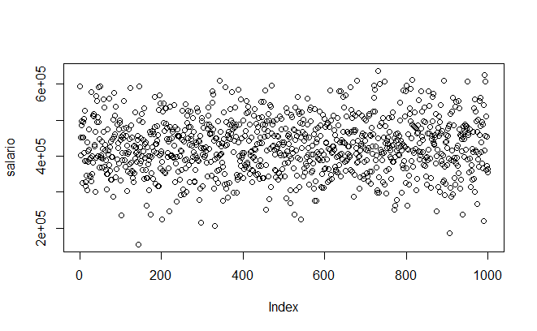

```r
# Generar variables y datos de muestra
# set.seed(123)
set.seed(sample(1:10000, 1))
salario_semanal <-300000
# experiencia(0 = Falso, 1 = Verdadero)
experiencia <- sample(0:10, 1000, replace = TRUE)
# Género (0 = Femenino, 1 = Masculino)
genero <- sample(c(0, 1), 1000, replace = TRUE)
# Universidad (0 = Pública, 1 =  Privada)
universidad <- sample(c(0, 1), 1000, replace = TRUE)

#valores
μ_gen <- (0.18 * salario_semanal)
μ_exp <- (0.05 * salario_semanal) # 35% en 5 años entonces 35/5 = 5% por año
μ_univ <- (0.17 * salario_semanal)
error_std_dev <- 50000 #tomando la mitad del valor salarial lo divido en 3 partes

# Salario semanal en pesos
salario <- salario_semanal + μ_gen * genero + μ_exp * experiencia + μ_univ * universidad + rnorm(1000, 0, error_std_dev)

dat <- data.frame(salario, genero, experiencia, universidad)
plot(salario)
```